# BayeScan

Óscar Romero Báez

2022-05-21

This analysis is part of my research project and this script will be used to analyze the results obtained from the BayeScan software from the SNP data obtained from four different sites where the *Sceloporus grammicus* lizard was sampled. For this proposal, the `plot_bayescan()` function that comes with the BayeScan software (Follows M and OE Gaggiotti, 2008) will be used to detect candidate loci under selection.

The format that BayeScan requires to run can be obtained using the PGDSpider program (Lischer HEL and Excoffier L, 2012). If you need to download both programs, go to the following links: http://cmpg.unibe.ch/software/BayeScan/download.html (BayeScan), http://www.cmpg.unibe.ch/software/PGDSpider/#Download_and_Installation_Instructions (PGDSpider).

Go to the **Sgrammicus_SelectionTest** folder to work with.

1. Run BayeScan

Parameters used to run BayeScan

Parameters All sites `Analysis/BayeScan/Program/BayeScan2.1_macos64bits Data/BayeScan/Sg_All_Bayescan` `-o Analysis/BayeScan/Results/Sg_All/Sg_All_Bayescan_RE1 -threads 4 -n 5000 -thin 20 -nbp 20 -pilot 1000 -burn 10000`

2. Required libraries

```r
library(ggplot2)
```

3. Source to plot_bayescan() function that comes with BayeScan

```r
source("Analysis/BayeScan/Program/plot_R.r")
```

4. Load BayeScan outputs

```r
#Output of all sites
Sg.all<-read.table("Analysis/BayeScan/Results/Sg_All/Sg_All_Bayescan_RE1_fst.txt",  #File path
                  header=F, #Indicates that the variables in the file do not have names
                  sep="", #Type of data separation
                  col.names=c("bayescan_number","prob",
                              "log10(PO)","qval","alpha","fst")) #Put names to variables of file

#Output of P6 sites
Sg.P6<-read.table("Analysis/BayeScan/Results/Sg_P6/Sg_P6_Bayescan_RE1_fst.txt", #File path
                  header=F, #Indicates that the variables in the file do not have names
                  sep="", #Type of data separation
                  col.names=c("bayescan_number","prob",
                              "log10(PO)","qval","alpha","fst")) #Put names to variables of file

#Output of P5 sites
Sg.P5<-read.table("Analysis/BayeScan/Results/Sg_P5/Sg_P5_BayeScan_RE1_fst.txt",  #File path
                  header=F, #Indicates that the variables in the file do not have names
                  sep="", #Type of data separation
                  col.names=c("bayescan_number","prob",
                              "log10(PO)","qval","alpha","fst")) #Put names to variables of file

#Loci info
Sg.loci<-read.table("Data/Loci_Info/Loci_info.txt",sep="\t",header=T)
```

### All sites

1. Analysis and plotting of the output of all sites

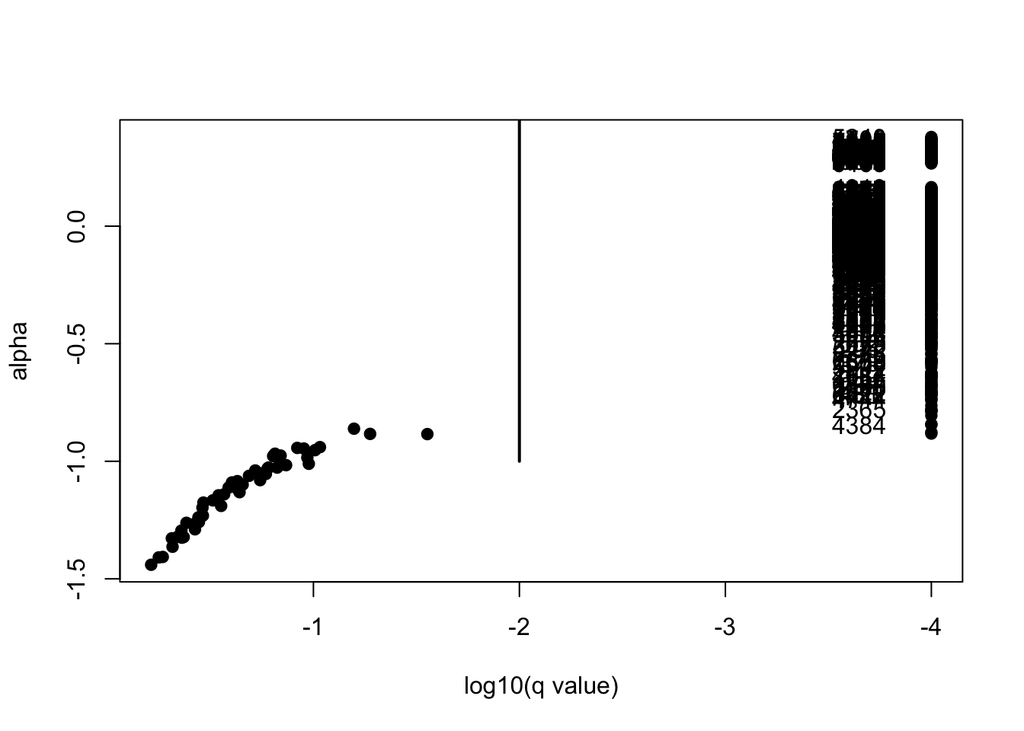

```r
#All sites
#Analysis of all sites using plot_bayescan function
Sg.all.res<-plot_bayescan(Sg.all, #Data
                          FDR=0.01) #False discovery rate
```

```r
#Review the number of outliers detected as candidates under selection
Sg.all.res$nb_outliers #Very large number!
```

```
## [1] 7548
```

2. False discovery rate correction

```r
#All sites
#Estimate the empirical cumulative distribution function (ECDF) for output
Likelihood_Function_A<-ecdf(Sg.all$alpha)
head(Likelihood_Function_A)
```

```
##
## 1 structure(function (v)
## 2 .approxfun(x, y, v, method, yleft, yright, f, na.rm), class = c("ecdf",
## 3 "stepfun", "function"), call = ecdf(Sg.all$alpha))
```

```r
#Function evaluation for output
#Run function
Eval_A<-Likelihood_Function_A(Sg.all[,"alpha"])
#Check results
head(Eval_A)
```

```
## [1] 0.05211212 0.05079616 0.52914857 0.16528491 0.57533886 0.14396631
```

```r
#Calculate the p-value, as 1 - the values of the previous results
Likelihood_Pval_A<-1-Eval_A

#Since many comparisons are made, it is necessary to correct the p-values, which make with the function p.adjust
Likelihood_FDR_A<-p.adjust(Likelihood_Pval_A,"BH") #Correction method used, known as False Discovery Rate
```

3. Create a new data frame with the results that includes the original data and the adjusted p-values

```r
#All sites
#Copy original data
Sg.All.res<-Sg.all

#Add p-values
Sg.All.res$pval<-Likelihood_Pval_A
Sg.All.res$pval.adjust<-Likelihood_FDR_A
head(Sg.All.res)
```

```
##   bayescan_number     prob log10.PO.     qval       alpha     fst      pval
## 1               1 0.140628 -0.786109 0.753468 -0.13638000 0.49372 0.9478879
## 2               2 0.134630 -0.808070 0.762160 -0.13886000 0.49354 0.9492038
## 3               3 0.059612 -1.198000 0.896300 -0.00012976 0.51846 0.4708514
## 4               4 0.094819 -0.979840 0.837830 -0.05424400 0.50851 0.8347151
## 5               5 0.070614 -1.119300 0.887640  0.00436300 0.51928 0.4246611
## 6               6 0.099220 -0.958020 0.828400 -0.06188100 0.50668 0.8560337
##   pval.adjust
## 1   0.9998612
## 2   0.9998614
## 3   0.9993483
## 4   0.9997027
## 5   0.9993483
## 6   0.9997027
```

```r
#Examine which ones are significant now
(Sg.outliers.bs.All<-Sg.loci[Sg.All.res$pval.adjust<=0.001,])
```

```
##       CHROM POS        ID
## 5240 190699  30 190699:30
```

```r
#Export outliers database
write.table(Sg.outliers.bs.All,file="Analysis/BayeScan/Results/Sg_outliers/Sg.All.outliers.BS.txt",row.names=F,col.names=T,quote=F)
```

4. Explore significant outliers with a plot

[figure not shown]

```r
#All sites
(Sg.All.out<-ggplot(Sg.All.res,aes(x=bayescan_number,y=fst))+ #Axis definition
                    geom_point(size=2,alpha=0.5, #Geometry definition
                    aes(colour=pval.adjust<=0.001))+ #Points color adjusted to p-val.adjust
                    scale_color_manual(values=c("black","red"))+ #Define point colors
                    theme_bw()+ #Canvas definition
                    ylab("Alpha")+ #y-lab name
                    xlab("Fst")+ #x-lab name
                    labs(color="Adjusted p-values")+ #Rename legend title
                    theme(axis.title.y=element_text(size=13), #y-axis title size
                    axis.title.x=element_text(size=13)))#+ #x-axis title size
```

```r
                    #annotate("text",x=0.56,y=0.44,label="190699:30",size=3.5)) #Add candidate SNP name
```

Save plot to pdf file

```r
ggsave("Analysis/BayeScan/Figures/Sg.All.out.pdf",dpi=300,limitsize=TRUE,
       width=10,height=7)
```

### P6 Sites

1. Analysis and plotting of the output of P6 Sites

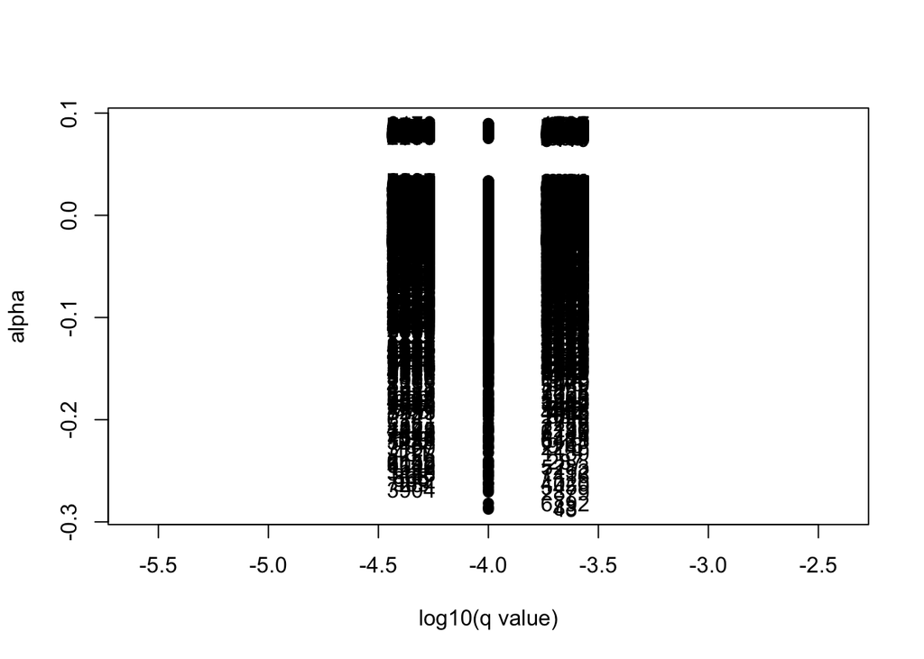

```r
#Analysis of P6 sites using plot_bayescan function
Sg.P6.res<-plot_bayescan(Sg.P6, #Data
                          FDR=0.01) #False discovery rate
```

```r
#Review the number of outliers detected as candidates under selection
Sg.P6.res$nb_outliers #Very large number!
```

```
## [1] 7599
```

2. False discovery rate correction

```r
#Estimate the empirical cumulative distribution function (ECDF) for output
Likelihood_Function_P6<-ecdf(Sg.P6$alpha)
head(Likelihood_Function_P6)
```

```
##
## 1 structure(function (v)
## 2 .approxfun(x, y, v, method, yleft, yright, f, na.rm), class = c("ecdf",
## 3 "stepfun", "function"), call = ecdf(Sg.P6$alpha))
```

```r
#Function evaluation for output
#Run function
Eval_P6<-Likelihood_Function_P6(Sg.P6[,"alpha"])
#Check results
head(Eval_P6)
```

```
## [1] 0.01789709 0.01579155 0.38662982 0.03829451 0.40531649 0.09632846
```

```r
#Calculate the p-value, as 1 - the values of the previous results
Likelihood_Pval_P6<-1-Eval_P6

#Since many comparisons are made, it is necessary to correct the p-values, which make with the function p.adjust
Likelihood_FDR_P6<-p.adjust(Likelihood_Pval_P6,"BH") #Correction method used, known as False Discovery Rate
```

3. Create a new data frame with the results that includes the original data and the adjusted p-values

```r
#Copy original data
Sg.P6.res<-Sg.P6

#Add p-values
Sg.P6.res$pval<-Likelihood_Pval_P6
Sg.P6.res$pval.adjust<-Likelihood_FDR_P6
head(Sg.P6.res)
```

```
##   bayescan_number     prob log10.PO.    qval     alpha     fst      pval
## 1               1 0.139823  -0.78901 0.83837 -0.144410 0.65048 0.9821029
## 2               2 0.140540  -0.78642 0.83745 -0.148250 0.64967 0.9842084
## 3               3 0.081122  -1.05410 0.90401 -0.018139 0.67817 0.6133702
## 4               4 0.119100  -0.86900 0.85536 -0.102550 0.65965 0.9617055
## 5               5 0.081762  -1.05040 0.90323 -0.017231 0.67830 0.5946835
## 6               6 0.098822  -0.95996 0.88719 -0.052802 0.67056 0.9036715
##   pval.adjust
## 1   0.9997325
## 2   0.9997327
## 3   0.9992038
## 4   0.9997265
## 5   0.9992038
## 6   0.9997236
```

```r
#Examine which ones are significant now
(Sg.outliers.P6.bs<-Sg.loci[Sg.P6.res$pval.adjust<=0.001,])
```

```
##      CHROM POS        ID
## 1728 73310 109 73310:109
```

```r
#Export outliers database
write.table(Sg.outliers.P6.bs,file="Analysis/BayeScan/Results/Sg_outliers/Sg.P6.outliers.BS.txt",row.names=F,col.names=T,quote=F)
```

4. Explore significant outliers with a plot

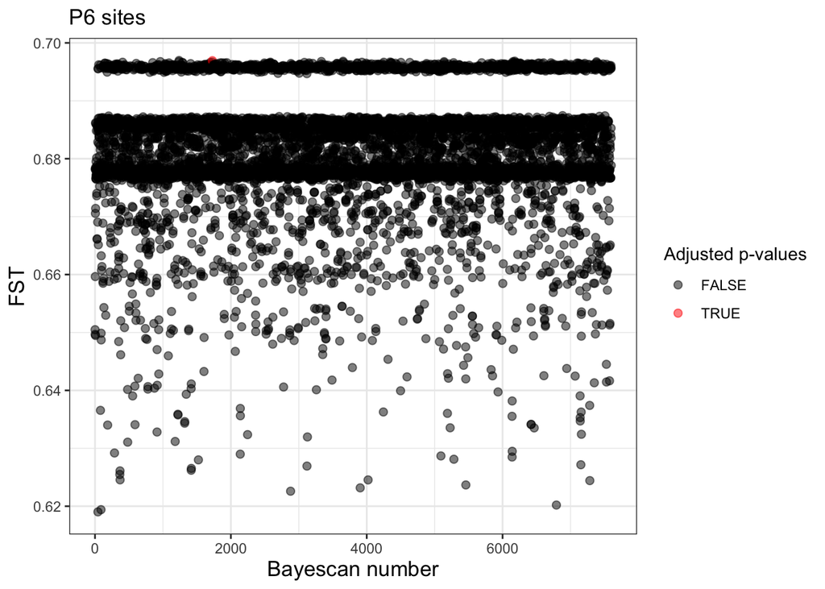

```r
(Sg.P6.out<-ggplot(Sg.P6.res,aes(x=bayescan_number,y=fst))+ #Axis definition
                    geom_point(size=2,alpha=0.5, #Geometry definition
                    aes(colour=pval.adjust<=0.001))+ #Points color adjusted to p-val.adjust
                    scale_color_manual(values=c("black","red"))+ #Define point colors
                    theme_bw()+ #Canvas definition
                    ylab("FST")+ #y-lab name
                    xlab("Bayescan number")+ #x-lab name
                    ggtitle("P6 sites")+ #Put title
                    labs(color="Adjusted p-values")+ #Rename legend title
                    theme(#plot.title=element_text(hjust=0.5), #Center title
                    axis.title.y=element_text(size=13), #y-axis title size
                    axis.title.x=element_text(size=13)))#+ #x-axis title size
```

```r
                    #annotate("text",x=0.69,y=0.09,label="73310:109",size=3)) #Add candidate SNP name
```

Save plot to pdf file

```r
ggsave("Analysis/BayeScan/Figures/Sg.P6.out.pdf",dpi=300,limitsize=TRUE,
       width=10,height=7)
```

### P5 Sites

1. Analysis and plotting of the output of P5 Sites

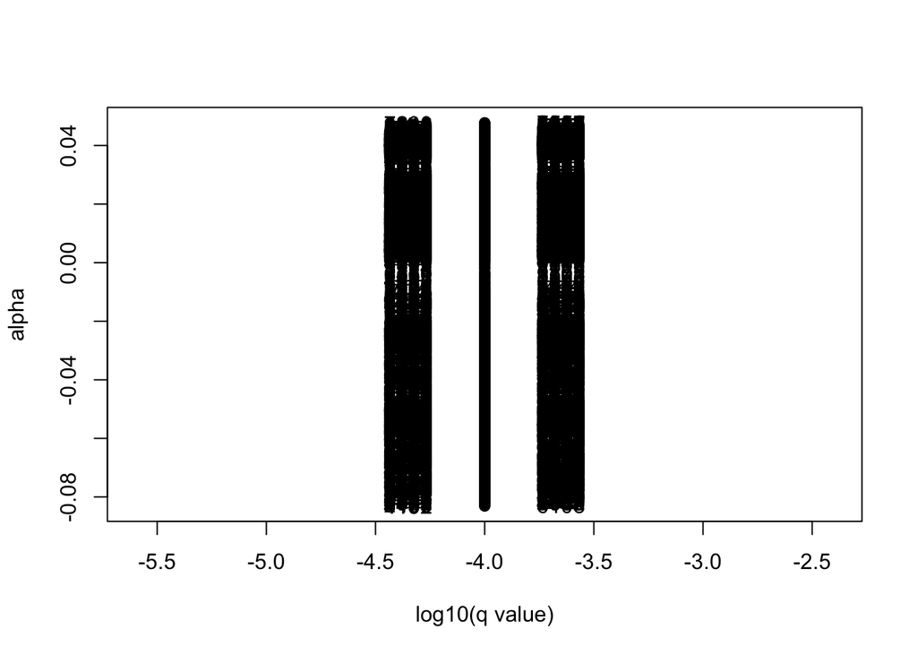

```r
#Analysis of P5 sites using plot_bayescan function
Sg.P5.res<-plot_bayescan(Sg.P5, #Data
                          FDR=0.01) #False discovery rate
```

```r
#Review the number of outliers detected as candidates under selection
Sg.P5.res$nb_outliers #Very large number!
```

```
## [1] 7599
```

2. False discovery rate correction

```r
#Estimate the empirical cumulative distribution function (ECDF) for output
Likelihood_Function_P5<-ecdf(Sg.P5$alpha)

#Function evaluation for output
#Run function
Eval_P5<-Likelihood_Function_P5(Sg.P5[,"alpha"])
#Check results
head(Eval_P5)
```

```
## [1] 0.4251875 0.4196605 0.6811423 0.9990788 0.6798263 0.2409528
```

```r
#Calculate the p-value, as 1 - the values of the previous results
Likelihood_Pval_P5<-1-Eval_P5

#Since many comparisons are made, it is necessary to correct the p-values, which make with the function p.adjust
Likelihood_FDR_P5<-p.adjust(Likelihood_Pval_P5,"BH") #Correction method used, known as False Discovery Rate
```

3. Create a new data frame with the results that includes the original data and the adjusted p-values

```r
#Copy original data
Sg.P5.res<-Sg.P5

#Add p-values
Sg.P5.res$pval<-Likelihood_Pval_P5
Sg.P5.res$pval.adjust<-Likelihood_FDR_P5
head(Sg.P5.res)
```

```
##   bayescan_number      prob log10.PO.     qval      alpha     fst         pval
## 1               1 0.0869817  -1.02105 0.901912  0.0063507 0.37207 0.5748124753
## 2               2 0.0872420  -1.01960 0.901760  0.0060500 0.37202 0.5803395184
## 3               3 0.0790620  -1.06630 0.907290  0.0221990 0.37437 0.3188577444
## 4               4 0.1076200  -0.91865 0.890820  0.0470740 0.37871 0.0009211738
## 5               5 0.0767220  -1.08040 0.909180  0.0221310 0.37436 0.3201737071
## 6               6 0.0833220  -1.04150 0.903550 -0.0292910 0.36634 0.7590472431
##   pval.adjust
## 1   0.9994471
## 2   0.9994471
## 3   0.9990440
## 4   0.8750000
## 5   0.9990440
## 6   0.9996577
```

```r
#Examine which ones are significant now
(Sg.outliers.P5.bs<-Sg.loci[Sg.P5.res$pval.adjust<=0.001,])
```

```
##       CHROM POS        ID
## 2906 116541  57 116541:57
```

```r
#Export outliers database
write.table(Sg.outliers.P5.bs,file="Analysis/BayeScan/Results/Sg_outliers/Sg.P5.outliers.BS.txt",row.names=F,col.names=T,quote=F)
```

4. Explore significant outliers with a plot

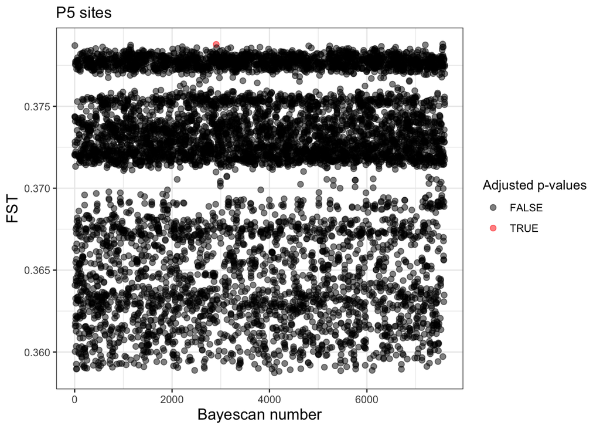

```r
(Sg.P5.out<-ggplot(Sg.P5.res,aes(x=bayescan_number,y=fst))+ #Axis definition
                   geom_point(size=2,alpha=0.5, #Geometry definition
                   aes(colour=pval.adjust<=0.001))+ #Points color adjusted to p-val.adjust
                   scale_color_manual(values=c("black","red"))+ #Define point colors
                   theme_bw()+ #Canvas definition
                   ylab("FST")+ #y-lab name
                   xlab("Bayescan number")+ #x-lab name
                   labs(color="Adjusted p-values")+ #Rename legend title
                   ggtitle("P5 sites")+ #Put title
                   theme(#plot.title=element_text(hjust=0.5), #Center title
                   axis.title.y=element_text(size=13), #y-axis title size
                   axis.title.x=element_text(size=13)))#+ #x-axis title size
```

```r
                   #annotate("text",x=0.31,y=0.198,label="L.1436",size=3)+ #Add candidate SNP name
                   #annotate("text",x=0.292,y=0.102,label="L.1437",size=3)) #Add candidate SNP name
```

Save plot to pdf file

```r
ggsave("Analysis/BayeScan/Figures/Sg.P5.out.pdf",dpi=300,limitsize=TRUE,
       width=10,height=7)
```